# Optimal Treatment Analysis

## Outcome Variable

**Outcome Variable:** haz

## Predictor Variables

**Intervention Variable:** fhtcm

**Adjustment Set:**

- arm
- W_mage
- W_fage
- meducyrs
- feducyrs
- W_mhtcm
- W_mwtkg
- W_mbmi
- single
- delta_W_mage
- delta_W_fage
- delta_meducyrs
- delta_feducyrs
- delta_W_mhtcm
- delta_W_mwtkg
- delta_W_mbmi
- delta_single

## Stratifying Variables

The analysis was stratified on these variable(s):

- agecat
- studyid
- country

## Data Summary

| agecat | studyid | country | fhtcm | n_cell | n |
| --- | --- | --- | --- | --- | --- |
| Birth | ki1000304b-SAS-CompFeed | INDIA | >=167 cm | 343 | 746 |
| Birth | ki1000304b-SAS-CompFeed | INDIA | <162 cm | 190 | 746 |
| Birth | ki1000304b-SAS-CompFeed | INDIA | [162-167) cm | 213 | 746 |
| Birth | ki1101329-Keneba | GAMBIA | >=167 cm | 772 | 1167 |
| Birth | ki1101329-Keneba | GAMBIA | <162 cm | 87 | 1167 |
| Birth | ki1101329-Keneba | GAMBIA | [162-167) cm | 308 | 1167 |
| Birth | ki1119695-PROBIT | BELARUS | >=167 cm | 11740 | 12533 |
| Birth | ki1119695-PROBIT | BELARUS | <162 cm | 168 | 12533 |
| Birth | ki1119695-PROBIT | BELARUS | [162-167) cm | 625 | 12533 |
| Birth | ki1135781-COHORTS | GUATEMALA | >=167 cm | 29 | 206 |
| Birth | ki1135781-COHORTS | GUATEMALA | <162 cm | 121 | 206 |
| Birth | ki1135781-COHORTS | GUATEMALA | [162-167) cm | 56 | 206 |
| 6 months | ki1000304b-SAS-CompFeed | INDIA | >=167 cm | 369 | 807 |
| 6 months | ki1000304b-SAS-CompFeed | INDIA | <162 cm | 194 | 807 |
| 6 months | ki1000304b-SAS-CompFeed | INDIA | [162-167) cm | 244 | 807 |
| 6 months | ki1000304b-SAS-FoodSuppl | INDIA | >=167 cm | 102 | 372 |
| 6 months | ki1000304b-SAS-FoodSuppl | INDIA | <162 cm | 148 | 372 |
| 6 months | ki1000304b-SAS-FoodSuppl | INDIA | [162-167) cm | 122 | 372 |
| 6 months | ki1101329-Keneba | GAMBIA | >=167 cm | 979 | 1511 |
| 6 months | ki1101329-Keneba | GAMBIA | <162 cm | 113 | 1511 |
| 6 months | ki1101329-Keneba | GAMBIA | [162-167) cm | 419 | 1511 |
| 6 months | ki1119695-PROBIT | BELARUS | >=167 cm | 11146 | 11895 |
| 6 months | ki1119695-PROBIT | BELARUS | <162 cm | 156 | 11895 |
| 6 months | ki1119695-PROBIT | BELARUS | [162-167) cm | 593 | 11895 |
| 6 months | ki1135781-COHORTS | GUATEMALA | >=167 cm | 45 | 336 |
| 6 months | ki1135781-COHORTS | GUATEMALA | <162 cm | 197 | 336 |
| 6 months | ki1135781-COHORTS | GUATEMALA | [162-167) cm | 94 | 336 |
| 24 months | ki1101329-Keneba | GAMBIA | >=167 cm | 821 | 1297 |
| 24 months | ki1101329-Keneba | GAMBIA | <162 cm | 97 | 1297 |
| 24 months | ki1101329-Keneba | GAMBIA | [162-167) cm | 379 | 1297 |
| 24 months | ki1119695-PROBIT | BELARUS | >=167 cm | 3445 | 3670 |
| 24 months | ki1119695-PROBIT | BELARUS | <162 cm | 53 | 3670 |
| 24 months | ki1119695-PROBIT | BELARUS | [162-167) cm | 172 | 3670 |
| 24 months | ki1135781-COHORTS | GUATEMALA | >=167 cm | 70 | 526 |
| 24 months | ki1135781-COHORTS | GUATEMALA | <162 cm | 307 | 526 |
| 24 months | ki1135781-COHORTS | GUATEMALA | [162-167) cm | 149 | 526 |

The following strata were considered:

- agecat: 24 months, studyid: ki1101329-Keneba, country: GAMBIA
- agecat: 24 months, studyid: ki1119695-PROBIT, country: BELARUS
- agecat: 24 months, studyid: ki1135781-COHORTS, country: GUATEMALA
- agecat: 6 months, studyid: ki1000304b-SAS-CompFeed, country: INDIA
- agecat: 6 months, studyid: ki1000304b-SAS-FoodSuppl, country: INDIA
- agecat: 6 months, studyid: ki1101329-Keneba, country: GAMBIA
- agecat: 6 months, studyid: ki1119695-PROBIT, country: BELARUS
- agecat: 6 months, studyid: ki1135781-COHORTS, country: GUATEMALA
- agecat: Birth, studyid: ki1000304b-SAS-CompFeed, country: INDIA
- agecat: Birth, studyid: ki1101329-Keneba, country: GAMBIA
- agecat: Birth, studyid: ki1119695-PROBIT, country: BELARUS
- agecat: Birth, studyid: ki1135781-COHORTS, country: GUATEMALA

## Methods Detail

We’re interested in the causal parameters $E[Y_a]$ for all values of $a \in \mathcal{A}$. These parameters represent the mean outcome if, possibly contrary to fact, we intervened to set all units to have $A=a$. Under the randomization and positivity assumptions, these are identified by the statistical parameters $\psi_a=E_W[E_{Y|A,W}(Y|A=a,W)]$. In addition, we’re interested in the mean of $Y$, $E[Y]$ under no intervention (the observed mean). We will estimate these parameters by using SuperLearner to fit the relevant likelihood factors – $E_{Y|A,W}(Y|A=a,W)$ and $p(A=a|W)$, and then updating our likelihood fit using a joint TMLE.

For unadjusted analyses ($W=\{\}$), initial likelihoods were estimated using Lrnr_glm to estimate the simple $E(Y|A)$ and Lrnr_mean to estimate $p(A)$. For adjusted analyses, a small library containing Lrnr_glmnet, Lrnr_xgboost, and Lrnr_mean was used.

Having estimated these parameters, we will then use the delta method to estimate relative risks and attributable risks relative to a prespecified baseline level of $A$.

# Results Detail

## Results Plots

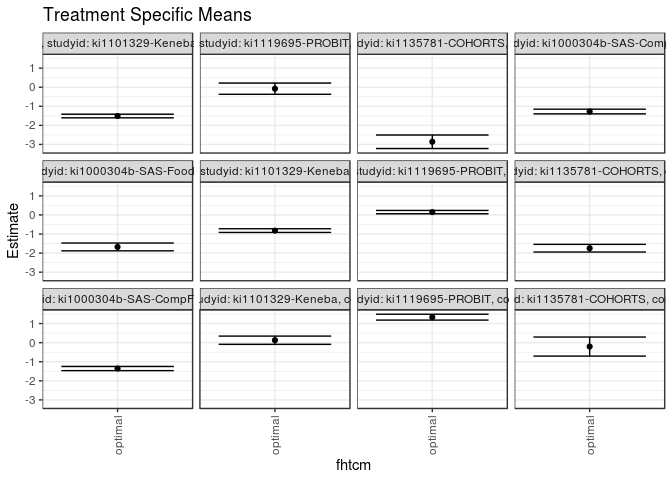

## Results Table

### Parameter: TSM

| agecat | studyid | country | intervention_level | baseline_level | estimate | ci_lower | ci_upper |
| --- | --- | --- | --- | --- | --- | --- | --- |
| Birth | ki1000304b-SAS-CompFeed | INDIA | optimal | observed | -1.3567859 | -1.4657847 | -1.2477871 |
| Birth | ki1101329-Keneba | GAMBIA | optimal | observed | 0.1283436 | -0.0879936 | 0.3446809 |
| Birth | ki1119695-PROBIT | BELARUS | optimal | observed | 1.3365294 | 1.1827064 | 1.4903524 |
| Birth | ki1135781-COHORTS | GUATEMALA | optimal | observed | -0.2053197 | -0.7044772 | 0.2938377 |
| 6 months | ki1000304b-SAS-CompFeed | INDIA | optimal | observed | -1.2737892 | -1.3973418 | -1.1502367 |
| 6 months | ki1000304b-SAS-FoodSuppl | INDIA | optimal | observed | -1.6772025 | -1.8813683 | -1.4730367 |
| 6 months | ki1101329-Keneba | GAMBIA | optimal | observed | -0.8214391 | -0.9179698 | -0.7249084 |
| 6 months | ki1119695-PROBIT | BELARUS | optimal | observed | 0.1483707 | 0.0598728 | 0.2368687 |
| 6 months | ki1135781-COHORTS | GUATEMALA | optimal | observed | -1.7433271 | -1.9435559 | -1.5430983 |
| 24 months | ki1101329-Keneba | GAMBIA | optimal | observed | -1.5094342 | -1.6050712 | -1.4137972 |
| 24 months | ki1119695-PROBIT | BELARUS | optimal | observed | -0.0762063 | -0.3704330 | 0.2180205 |
| 24 months | ki1135781-COHORTS | GUATEMALA | optimal | observed | -2.8592175 | -3.2143098 | -2.5041252 |

### Parameter: E(Y)

| agecat | studyid | country | intervention_level | baseline_level | estimate | ci_lower | ci_upper |
| --- | --- | --- | --- | --- | --- | --- | --- |
| Birth | ki1000304b-SAS-CompFeed | INDIA | observed | observed | -1.4650804 | -1.5752607 | -1.3549001 |
| Birth | ki1101329-Keneba | GAMBIA | observed | observed | 0.0702057 | -0.0035933 | 0.1440046 |
| Birth | ki1119695-PROBIT | BELARUS | observed | observed | 1.3367673 | 1.1803545 | 1.4931801 |
| Birth | ki1135781-COHORTS | GUATEMALA | observed | observed | -0.2367476 | -0.3941046 | -0.0793906 |
| 6 months | ki1000304b-SAS-CompFeed | INDIA | observed | observed | -1.4400743 | -1.5370187 | -1.3431300 |
| 6 months | ki1000304b-SAS-FoodSuppl | INDIA | observed | observed | -1.8871505 | -1.9993302 | -1.7749709 |
| 6 months | ki1101329-Keneba | GAMBIA | observed | observed | -0.9321551 | -0.9872314 | -0.8770788 |
| 6 months | ki1119695-PROBIT | BELARUS | observed | observed | 0.1203779 | 0.0296502 | 0.2111056 |
| 6 months | ki1135781-COHORTS | GUATEMALA | observed | observed | -1.9652976 | -2.0794998 | -1.8510954 |
| 24 months | ki1101329-Keneba | GAMBIA | observed | observed | -1.6200950 | -1.6766111 | -1.5635788 |
| 24 months | ki1119695-PROBIT | BELARUS | observed | observed | -0.1266303 | -0.4286611 | 0.1754004 |
| 24 months | ki1135781-COHORTS | GUATEMALA | observed | observed | -3.0347529 | -3.1289563 | -2.9405494 |

### Parameter: PAR

| agecat | studyid | country | intervention_level | baseline_level | estimate | ci_lower | ci_upper |
| --- | --- | --- | --- | --- | --- | --- | --- |
| Birth | ki1000304b-SAS-CompFeed | INDIA | optimal | observed | -0.1082946 | -0.2069454 | -0.0096437 |
| Birth | ki1101329-Keneba | GAMBIA | optimal | observed | -0.0581380 | -0.2566684 | 0.1403925 |
| Birth | ki1119695-PROBIT | BELARUS | optimal | observed | 0.0002379 | -0.0193753 | 0.0198511 |
| Birth | ki1135781-COHORTS | GUATEMALA | optimal | observed | -0.0314278 | -0.4736617 | 0.4108060 |
| 6 months | ki1000304b-SAS-CompFeed | INDIA | optimal | observed | -0.1662851 | -0.2269267 | -0.1056435 |
| 6 months | ki1000304b-SAS-FoodSuppl | INDIA | optimal | observed | -0.2099481 | -0.3865629 | -0.0333332 |
| 6 months | ki1101329-Keneba | GAMBIA | optimal | observed | -0.1107160 | -0.1924481 | -0.0289839 |
| 6 months | ki1119695-PROBIT | BELARUS | optimal | observed | -0.0279928 | -0.0350249 | -0.0209608 |
| 6 months | ki1135781-COHORTS | GUATEMALA | optimal | observed | -0.2219705 | -0.4065179 | -0.0374232 |
| 24 months | ki1101329-Keneba | GAMBIA | optimal | observed | -0.1106607 | -0.1889689 | -0.0323525 |
| 24 months | ki1119695-PROBIT | BELARUS | optimal | observed | -0.0504241 | -0.1011899 | 0.0003417 |
| 24 months | ki1135781-COHORTS | GUATEMALA | optimal | observed | -0.1755353 | -0.5168646 | 0.1657940 |